# StockResearch

Gabriel Foix

2021-03-24

Buy Quality at the a good momentum and get rid of the fishy stocks on time. That's all.

### Define candidates

#### Download Key Stats

```r
KeyStatistics.list <- YHFinR::getYFKeyStatistics(Candidates.df$Ticker)
```

[output not shown]

[output not shown]

[output not shown]

[output not shown]

[output not shown]

[output not shown]

[output not shown]

[output not shown]

[output not shown]

[output not shown]

[output not shown]

[output not shown]

[output not shown]

[output not shown]

[output not shown]

[output not shown]

[output not shown]

[output not shown]

[output not shown]

[output not shown]

[output not shown]

[output not shown]

[output not shown]

[output not shown]

[output not shown]

[output not shown]

[output not shown]

[output not shown]

[output not shown]

[output not shown]

[output not shown]

[output not shown]

[output not shown]

[output not shown]

[output not shown]

[output not shown]

[output not shown]

[output not shown]

[output not shown]

[output not shown]

[output not shown]

[output not shown]

[output not shown]

[output not shown]

[output not shown]

[output not shown]

[output not shown]

[output not shown]

[output not shown]

[output not shown]

[output not shown]

[output not shown]

[output not shown]

[output not shown]

[output not shown]

[output not shown]

[output not shown]

[output not shown]

[output not shown]

[output not shown]

[output not shown]

[output not shown]

[output not shown]

[output not shown]

[output not shown]

[output not shown]

[output not shown]

[output not shown]

[output not shown]

[output not shown]

[output not shown]

[output not shown]

[output not shown]

[output not shown]

[output not shown]

[output not shown]

[output not shown]

[output not shown]

[output not shown]

[output not shown]

[output not shown]

[output not shown]

[output not shown]

[output not shown]

[output not shown]

[output not shown]

[output not shown]

[output not shown]

[output not shown]

[output not shown]

[output not shown]

[output not shown]

[output not shown]

```r
# Save temp in case
remove("KeyStatistics.list.tmp.rds")
saveRDS(KeyStatistics.list, "KeyStatistics.list.tmp.rds")
# KeyStatistics.list <- readRDS("KeyStatistics.list.tmp.rds")
```

Filter by EV & EPS

#### Download Historical Data

Download only stocks not filtered previously Filter by historical data < 1 year

#### Download Financiall Basics

### Factor 1: Quality

1. Healthy debts: A company shoud generate cash in order to repay its debt. The **Free Cash Flow to Debt** ratio is a good indicator of how quick a company pays back its debt. The lower this ratio the better.

FCF2D = $\frac{Debt}{Free Cash Flow}$

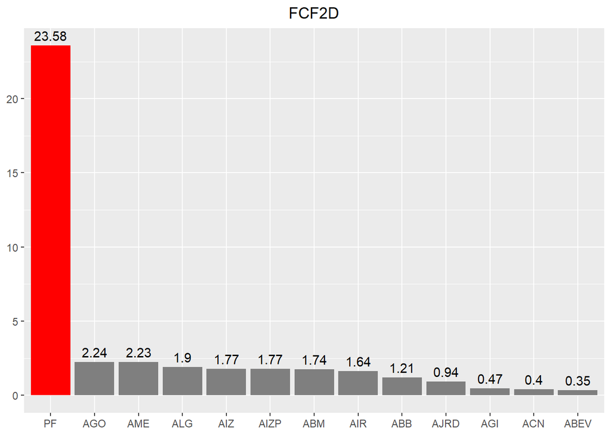

2. Profitability: ROA

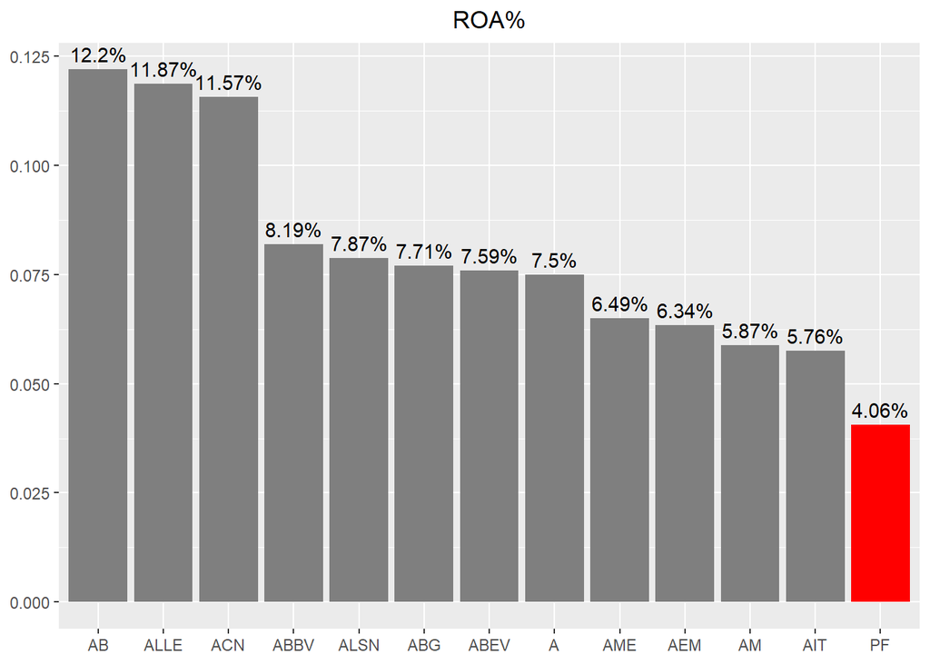

3. High Margin: We look for companies that generate free cash flow compare to its price. The **Free Cash Flow to Entreprise Value** ratio tells us how many years of cash flow would be needed to the return the 100% of the investment. Again, the lower, the better. Values bellow 1 would mean "free lunch".

FCF2EV = $\frac{EV}{Free Cash Flow}$

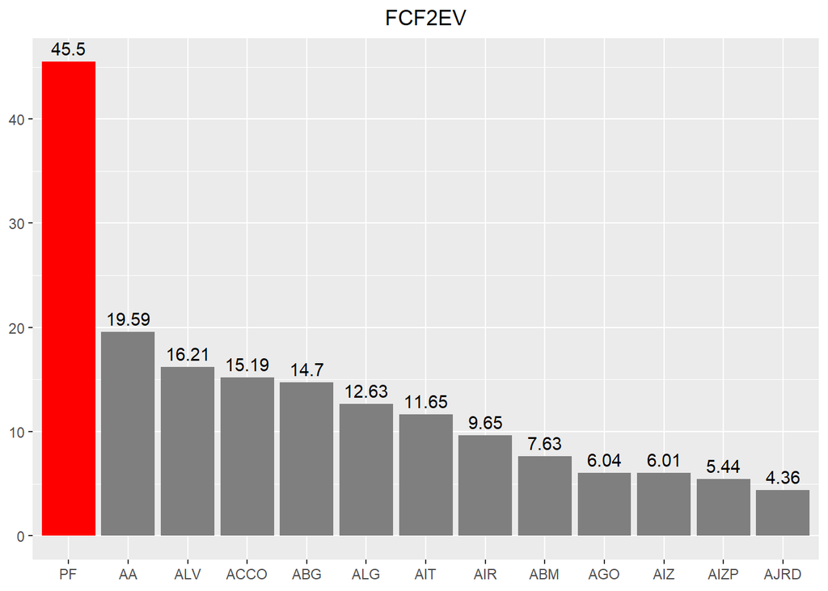

### Value touch

Filter out stocks with PER > 40

Report Candidates

Filter Summary

[output not shown]

### Factor 2: Momentum

Don't hold onto a stock simply because it is high quality. So called quality stocks have cycles too. Stan Weinstein (page 177)

Generic Intermediate-Term Momentum Based on Gray-Vogel (page 80)

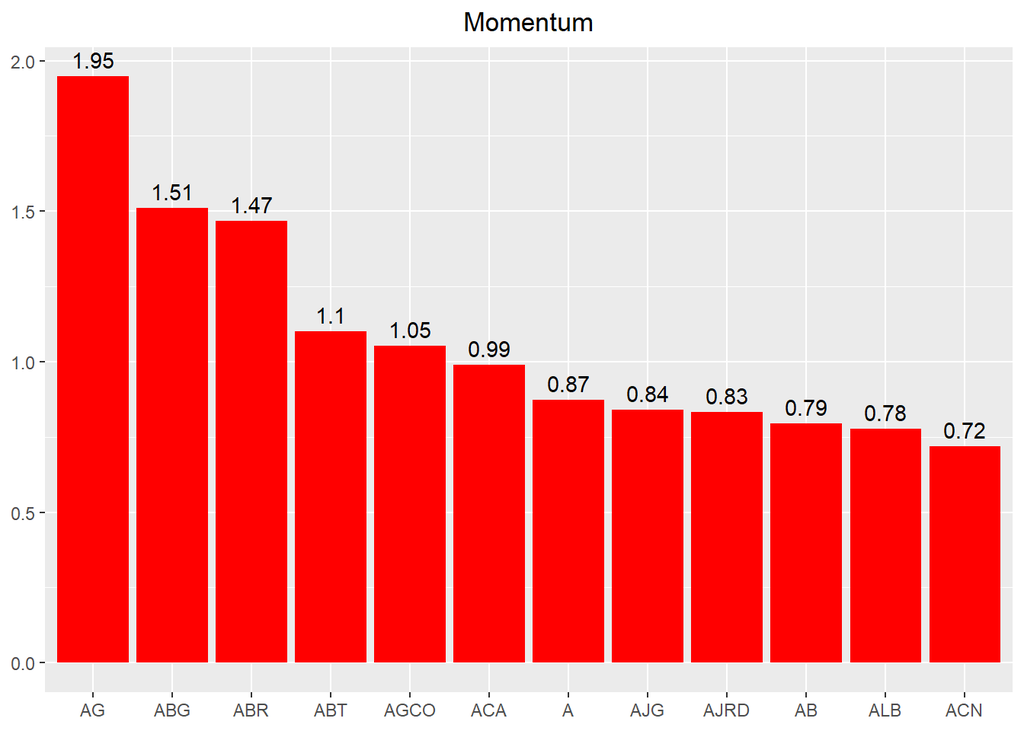

### Factor 3: Timing Signal

Sell Signal - Pr < 1% SMA 30 weeks and slope negative (< -0.2)  
Buy Signal - 109% * SMA30 < Pr > SMA 30 and slope positive (> 0.2)  
Hold Signal - Neither Buy nor Sell

#### Calc Market Cap

Using free float shares

### Summary

Summary

| Ticker | Signal | Quality | Momentum | Final_rank | PER | MCap |
| --- | --- | --- | --- | --- | --- | --- |
| AB | HOLD | 54.0 | 45 | 54.0 | 13.869625 | 3904089400 |
| ABR | HOLD | 46.0 | 52 | 53.0 | 11.370739 | 1861751134 |
| ACN | BUY | 53.0 | 43 | 51.0 | 31.662720 | 169785090148 |
| AGCO | HOLD | 45.0 | 50 | 49.5 | 24.132744 | 8468394410 |
| AME | BUY | 51.0 | 42 | 48.0 | 32.575596 | 28179919407 |
| AJRD | BUY | 43.0 | 46 | 47.0 | 28.307230 | 3316509020 |
| ABG | HOLD | 33.0 | 53 | 46.0 | 13.761761 | 3095770163 |
| AEM | SELL | 47.0 | 35 | 45.0 | 27.933333 | 14213399618 |
| AJG | BUY | 32.0 | 47 | 44.0 | 29.576191 | 23813926629 |
| ACA | BUY | 29.5 | 49 | 43.0 | 26.284403 | 2724334652 |
| ABBV | HOLD | 48.0 | 30 | 41.5 | 37.889705 | 179081714398 |
| ALLE | HOLD | 50.0 | 28 | 41.5 | 35.884956 | 10977870705 |
| ACRE | HOLD | 34.0 | 40 | 39.5 | 21.030303 | 441981926 |
| ABB | HOLD | 41.0 | 32 | 37.5 | 12.653815 | 51129672782 |
| ALG | BUY | 36.0 | 37 | 37.5 | 30.644351 | 1689647923 |
| AAP | HOLD | 37.0 | 33 | 36.0 | 25.452380 | 11768402733 |
| AGI | SELL | 28.0 | 36 | 33.5 | 21.141305 | 3042297101 |
| ALL | HOLD | 42.0 | 22 | 33.5 | 6.519353 | 33995381216 |
| AIZ | HOLD | 19.0 | 39 | 31.0 | 20.306020 | 8127513704 |
| AMCR | HOLD | 38.0 | 19 | 29.5 | 36.134187 | 17555181605 |
| ADM | HOLD | 17.0 | 38 | 28.0 | 17.752380 | 31083184274 |
| ABEV | BUY | 52.0 | 1 | 26.5 | 20.538462 | 11737375212 |
| AEE | HOLD | 22.0 | 31 | 26.5 | 23.139999 | 20388521923 |
| AJX | HOLD | 39.0 | 13 | 25.0 | 11.091091 | 237366118 |
| ADC | HOLD | 10.5 | 41 | 24.0 | 38.396550 | 4134999959 |
| AGO | HOLD | 23.5 | 26 | 23.0 | 10.019093 | 3049317389 |
| AIZP | HOLD | 20.0 | 29 | 22.0 | 18.235378 | 7309221007 |
| ALSN | HOLD | 31.0 | 12 | 21.0 | 15.213741 | 4185786516 |
| AL | HOLD | 23.5 | 18 | 20.0 | 10.630979 | 4450252025 |
| AEP | HOLD | 18.0 | 23 | 18.5 | 19.228506 | 42153631421 |
| AFL | HOLD | 21.0 | 20 | 18.5 | 7.481260 | 34106228839 |
| AIF | HOLD | 14.5 | 21 | 16.0 | 31.153039 | 0 |
| ADS | HOLD | 25.5 | 2 | 13.0 | 23.802376 | 5125958632 |
| AFG | HOLD | 10.5 | 16 | 12.0 | 13.959756 | 7668111176 |
| AGR | HOLD | 12.0 | 10 | 8.5 | 25.849760 | 2760769734 |
| AHH | HOLD | 6.0 | 14 | 6.0 | 33.289473 | 735903039 |
| ALX | BUY | 13.0 | 6 | 5.0 | 34.409035 | 1064164431 |
| ACCO | BUY | 14.5 | 4 | 4.0 | 12.215385 | 727504300 |
| ALE | HOLD | 1.0 | 9 | 1.0 | 20.080596 | 3491265939 |

Save output in template